# Centrality

Felix Lennert

2020-07-09

# Einführung

Welche Akteure haben den größten Stellenwert in einem Netzwerk, sprich, sind zentraler? Diese Frage ist eine der ältesten in der Netzwerkforschung und wurde so ähnlich schon von Moreno (in den 1930ern) gestellt. Im Laufe der Jahre wurden einige Konzepte und Maßzahlen eingeführt. Laut Freeman (1978), können diese in drei Kategorien gesteckt werden: degree centrality, betweenness centrality und closeness centrality (Freeman 1978). Um diese wird es im Folgenden gehen.

Eine Übersicht über gängige Zentralitätsmaße, zusammengetragen von David Schoch, kann [hier](http://schochastics.net/sna/periodic.html) gefunden werden.

# Degree centrality

Die Grundidee hinter degree centrality ist, dass derjenige Akteur, der die meisten Verbindungen, ergo den höchsten Degree, hat, auch die zentralste Position im Netzwerk inne hat.

## Eigenvector centrality

Eine Erweiterung der degree centrality ist die sogenannte eigenvector centrality. Diese berücksichtigt die Zentralität anderer Nachbarn. Ein Akteur kann auch eine hohe eigenvector centrality haben, wenn er weniger Verbindungen hat, diese aber mit “wichtigen” Akteuren, sprich Akteuren mit hoher eigenvector centrality.

## PageRank und HITS

Eine modernere Adaption dieser Überlegungen sind die beiden Algorithmen PageRank und HITS. Diese werden in gesonderten Referaten behandelt.

# Betweenness centrality

Die Überlegung hinter der betweenness centrality ist, dass Akteure, welche auf den Pfaden zwischen verschiedenen Akteuren liegen, zentraler sind.

Auch dies macht intuitiv Sinn: Man denke an ein Netzwerk von Freunden, welche Gerüchte verbreiten. Wer auf den Pfaden zwischen den verschiedenen Akteuren ist, hat eine gewisse Gatekeeper-Funktion inne und kann entscheiden, welche Gerüchte weitergegeben werden.

Haben Akteure mit hoher betweenness centrality auch zwangsläufig eine hohe degree centralitx? Hier kann man an verschiedene Freundesgruppen denken. Manche Akteure verbinden diese, haben aber nur wenige Verbindungen selbst. Nichtsdestotrotz liegt A auf allen Pfaden zwischen diesen Gruppen.

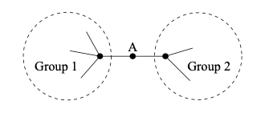

Aus (Newman 2010)

# Closeness Centrality

Closeness centrality beinhaltet, wie der Name schon sagt, wie weit ein Akteur von anderen entfernt ist. Dies wird in der durchschnittlichen geodätischen Distanz von einem Knoten zu allen anderen abgebildet. Die geodätische Distanz zwischen i und j ist die kürzeste Strecke zwischen den beiden, ausgedrückt in der Anzahl an edges zwischen den beiden.

# In `tidygraph`

In `tidygraph` gibt es einige Funktionen zur Berechnung von centrality. Sie alle haben als suffix `centrality_`.

```r
library(tidygraph)
net <- play_erdos_renyi(20, 0.3, directed = FALSE)


net %>%
  mutate(name = 1:20,
         degree_centrality = centrality_degree(),
         betwenness_centrality = centrality_betweenness(directed = FALSE),
         closeness_centrality = centrality_closeness_harmonic())
```

```
## # A tbl_graph: 20 nodes and 61 edges
## #
## # An undirected simple graph with 1 component
## #
## # Node Data: 20 x 4 (active)
##    name degree_centrality betwenness_centrality closeness_centrality
##   <int>             <dbl>                 <dbl>                <dbl>
## 1     1                 5                 1.73                 11.8
## 2     2                 8                 9.98                 13.5
## 3     3                 5                 0.668                11.7
## 4     4                 5                 1.93                 11.8
## 5     5                10                16.7                  14.5
## 6     6                 2                 0.25                  9.33
## # … with 14 more rows
## #
## # Edge Data: 61 x 2
##    from    to
##   <int> <int>
## 1     2     3
## 2     3     5
## 3     4     5
## # … with 58 more rows
```

# 9/11 Hijackers

```r
library(tidyverse)
```

```r
library(igraph)
adj_tbl <- read_csv("data/911_hijackers.csv") %>%
  column_to_rownames(var = "X1")
graph <- graph_from_adjacency_matrix(as.matrix(adj_tbl), mode = "undirected")

centrality_tibble <- graph %>%
  as_tbl_graph() %>%
  mutate(degree_centrality = centrality_eigen(),
         betwenness_centrality = centrality_betweenness(directed = FALSE),
         closeness_centrality = centrality_closeness_harmonic()) %>%
  as_tibble()
```

# Hausaufgabe bis Montag

- Was habt ihr für Ideen für Euer Paper?
  - Forschungsfrage
  - Methode
  - Datensatz
- https://github.com/briatte/awesome-network-analysis –

# Literatur

Freeman, Linton. 1978. “Centrality in Social Networks: Conceptual Clarification.” *Social Networks* 1(1):215–39.

Newman, M. E. J. 2010. *Networks: An Introduction*. Oxford ; New York: Oxford University Press.